# act_report

## Twitter's @WeRateDogs Tweet Analysis Report

**Udacity Data Analyst Nano Degree**

*Term 2: Data Wrangling*

By Calvert Louden Jr.

```python
# making the necessary imports
import pandas as pd
from pandas import Series,DataFrame

import numpy as np
import os

import matplotlib.pyplot as plt
%matplotlib inline
import matplotlib.ticker as ticker

import seaborn as sns
plt.style.use('seaborn')

from IPython.core.display import Image, display, HTML

import requests
from io import BytesIO
import PIL
```

I loved this project! It did give me headaches, but as a dog lover myself, it was awesome to take a break from the task at hand and randomly look up photos of dogs from the data I was working with. They are quite the belly buster, some of them, but my beauty Bella still reigns queen for me.

```python
folder_name = 'img'

if not os.path.exists(folder_name):
    os.makedirs(folder_name)
```

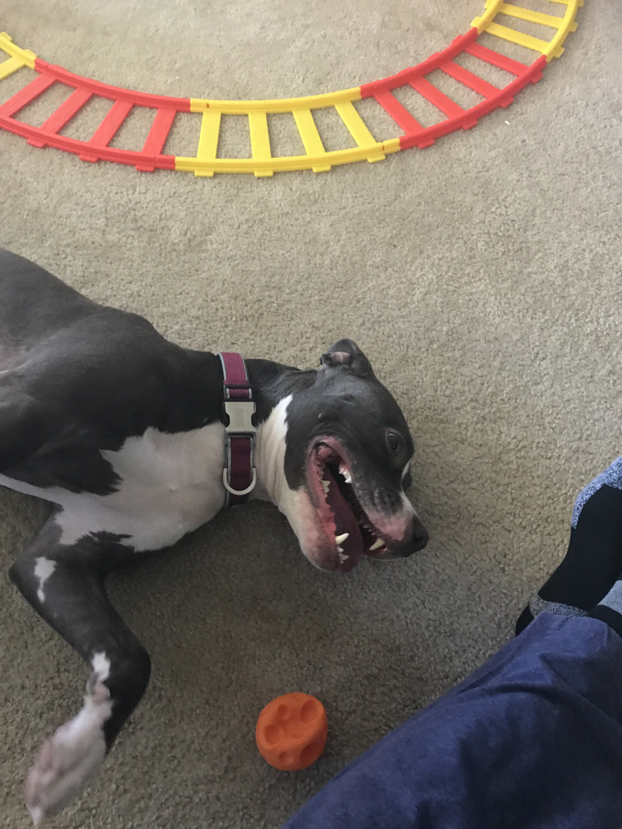

```python
Image('img/IMG_6682.jpeg')
```

After importing, downloading and querying Twitter's API I was left with a few sets of data that needed a bit of finnessing. During my assessment of the tidyness, and data quality dimensional issues I'd encountered, I started to also think about how I would use the cleaned data for analysis. Below, you will find brief explanations regarding the twitter analysis I've conducted.

### Twitter Archive Dataset

```python
twt_ar_df = pd.read_csv('twitter_archive_master.csv')

twt_ar_df.head(3)
```

|  | tweet_id | timestamp | source | text | rating_numerator | rating_denominator | name | tweet_status_url | dog_stage | jpg_url | ... | p2 | p2_conf | p2_dog | p3 | p3_conf | p3_dog | favorites | favorited | retweets | retweeted |
| --- | --- | --- | --- | --- | --- | --- | --- | --- | --- | --- | --- | --- | --- | --- | --- | --- | --- | --- | --- | --- | --- |
| 0 | 8.924206e+17 | 2017-08-01 16:23:56 | "http://twitter.com/download/iphone" rel="nofo... | This is Phineas. He's a mystical boy. Only eve... | 13.0 | 10.0 | Phineas | https://twitter.com/dog_rates/status/892420643... | NaN | https://pbs.twimg.com/media/CT4udn0WwAA0aMy.jpg | ... | collie | 0.156665 | True | Shetland_sheepdog | 0.061428 | True | 37997.0 | False | 8308.0 | False |
| 1 | 8.921774e+17 | 2017-08-01 00:17:27 | "http://twitter.com/download/iphone" rel="nofo... | This is Tilly. She's just checking pup on you.... | 13.0 | 10.0 | Tilly | https://twitter.com/dog_rates/status/892177421... | NaN | https://pbs.twimg.com/media/CT42GRgUYAA5iDo.jpg | ... | miniature_pinscher | 0.074192 | True | Rhodesian_ridgeback | 0.072010 | True | 32628.0 | False | 6138.0 | False |
| 2 | 8.918152e+17 | 2017-07-31 00:18:03 | "http://twitter.com/download/iphone" rel="nofo... | This is Archie. He is a rare Norwegian Pouncin... | 12.0 | 10.0 | Archie | https://twitter.com/dog_rates/status/891815181... | NaN | https://pbs.twimg.com/media/CT4521TWwAEvMyu.jpg | ... | malinois | 0.138584 | True | bloodhound | 0.116197 | True | 24551.0 | False | 4062.0 | False |

3 rows × 24 columns

```python
twt_ar_df.info()
```

```
<class 'pandas.core.frame.DataFrame'>
RangeIndex: 2356 entries, 0 to 2355
Data columns (total 24 columns):
tweet_id              2097 non-null float64
timestamp             2097 non-null object
source                2097 non-null object
text                  2097 non-null object
rating_numerator      2096 non-null float64
rating_denominator    2097 non-null float64
name                  1321 non-null object
tweet_status_url      2097 non-null object
dog_stage             353 non-null object
jpg_url               2075 non-null object
img_num               2075 non-null float64
p1                    2075 non-null object
p1_conf               2075 non-null float64
p1_dog                2075 non-null object
p2                    2075 non-null object
p2_conf               2075 non-null float64
p2_dog                2075 non-null object
p3                    2075 non-null object
p3_conf               2075 non-null float64
p3_dog                2075 non-null object
favorites             2340 non-null float64
favorited             2340 non-null object
retweets              2340 non-null float64
retweeted             2340 non-null object
dtypes: float64(9), object(15)
memory usage: 441.8+ KB
```

```python
# taking a look at value counts for the 'source' column
twt_ar_df['source'].value_counts()
```

```
"http://twitter.com/download/iphone" rel="nofollow" Twitter for iPhone     1964
"http://vine.co" rel="nofollow" Vine - Make a Scene                          91
"http://twitter.com" rel="nofollow" Twitter Web Client                       31
"https://about.twitter.com/products/tweetdeck" rel="nofollow" TweetDeck      11
Name: source, dtype: int64
```

```
Text(0,0.5,'Source of Tweets')
```

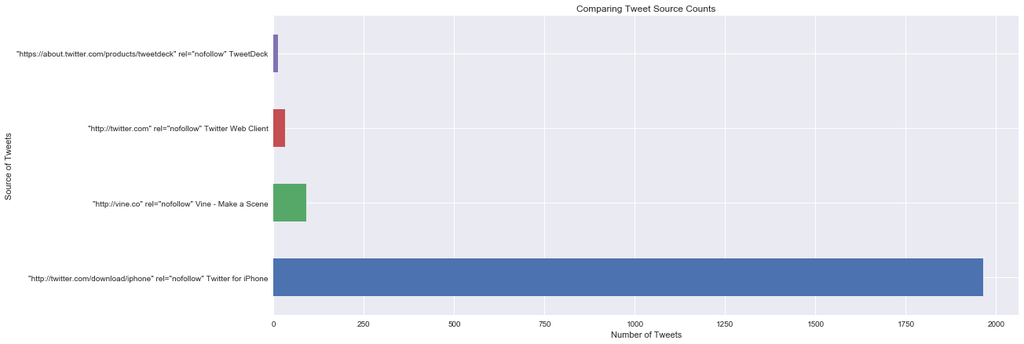

```python
twt_ar_df['source'].value_counts().plot(kind='barh', figsize=(17, 7))

# setting my labels
plt.title('Comparing Tweet Source Counts')
plt.xlabel('Number of Tweets')
plt.ylabel('Source of Tweets')
```

### Image Prediction Dataset

```python
img_prd_df_cln = pd.read_csv('image_prediction_cln.csv')

img_prd_df_cln.head()
```

|  | tweet_id | jpg_url | img_num | p1 | p1_conf | p1_dog | p2 | p2_conf | p2_dog | p3 | p3_conf | p3_dog |
| --- | --- | --- | --- | --- | --- | --- | --- | --- | --- | --- | --- | --- |
| 0 | 666020888022790149 | https://pbs.twimg.com/media/CT4udn0WwAA0aMy.jpg | 1 | Welsh_springer_spaniel | 0.465074 | True | collie | 0.156665 | True | Shetland_sheepdog | 0.061428 | True |
| 1 | 666029285002620928 | https://pbs.twimg.com/media/CT42GRgUYAA5iDo.jpg | 1 | redbone | 0.506826 | True | miniature_pinscher | 0.074192 | True | Rhodesian_ridgeback | 0.072010 | True |
| 2 | 666033412701032449 | https://pbs.twimg.com/media/CT4521TWwAEvMyu.jpg | 1 | German_shepherd | 0.596461 | True | malinois | 0.138584 | True | bloodhound | 0.116197 | True |
| 3 | 666044226329800704 | https://pbs.twimg.com/media/CT5Dr8HUEAA-lEu.jpg | 1 | Rhodesian_ridgeback | 0.408143 | True | redbone | 0.360687 | True | miniature_pinscher | 0.222752 | True |
| 4 | 666049248165822465 | https://pbs.twimg.com/media/CT5IQmsXIAAKY4A.jpg | 1 | miniature_pinscher | 0.560311 | True | Rottweiler | 0.243682 | True | Doberman | 0.154629 | True |

In order to assess and analyze the difference or variance between p1 predictions and p2 or p3 predicitions, I had to create three columns that measure the variances between p1 & p2 prediction confidence percentages, p1 & p3 prediction confidence percentages, and lastly p2 & p3 prediction confidence percentages; I named those columns `p1_p2_var,` `p1_p3_var` and `p2_p3_var`.

My goal here was to hopefully explore any anomalies that may lay hidden within the data, specifically prediction confidence percentages for the algorithm's 'educated guesses or predictions'. First, I'll display the visualizations, then I'll explain the analysis.

```python
# creating my variance columns
img_prd_df_cln['p1_p2_var'] = (img_prd_df_cln['p1_conf'] - img_prd_df_cln['p2_conf'])
img_prd_df_cln['p2_p3_var'] = (img_prd_df_cln['p2_conf'] - img_prd_df_cln['p3_conf'])
img_prd_df_cln['p1_p3_var'] = (img_prd_df_cln['p1_conf'] - img_prd_df_cln['p3_conf'])
```

```python
img_prd_df_cln.head()
```

|  | tweet_id | jpg_url | img_num | p1 | p1_conf | p1_dog | p2 | p2_conf | p2_dog | p3 | p3_conf | p3_dog | p1_p2_var | p2_p3_var | p1_p3_var |
| --- | --- | --- | --- | --- | --- | --- | --- | --- | --- | --- | --- | --- | --- | --- | --- |
| 0 | 666020888022790149 | https://pbs.twimg.com/media/CT4udn0WwAA0aMy.jpg | 1 | Welsh_springer_spaniel | 0.465074 | True | collie | 0.156665 | True | Shetland_sheepdog | 0.061428 | True | 0.308409 | 0.095237 | 0.403646 |
| 1 | 666029285002620928 | https://pbs.twimg.com/media/CT42GRgUYAA5iDo.jpg | 1 | redbone | 0.506826 | True | miniature_pinscher | 0.074192 | True | Rhodesian_ridgeback | 0.072010 | True | 0.432634 | 0.002182 | 0.434816 |
| 2 | 666033412701032449 | https://pbs.twimg.com/media/CT4521TWwAEvMyu.jpg | 1 | German_shepherd | 0.596461 | True | malinois | 0.138584 | True | bloodhound | 0.116197 | True | 0.457877 | 0.022387 | 0.480264 |
| 3 | 666044226329800704 | https://pbs.twimg.com/media/CT5Dr8HUEAA-lEu.jpg | 1 | Rhodesian_ridgeback | 0.408143 | True | redbone | 0.360687 | True | miniature_pinscher | 0.222752 | True | 0.047456 | 0.137935 | 0.185391 |
| 4 | 666049248165822465 | https://pbs.twimg.com/media/CT5IQmsXIAAKY4A.jpg | 1 | miniature_pinscher | 0.560311 | True | Rottweiler | 0.243682 | True | Doberman | 0.154629 | True | 0.316629 | 0.089053 | 0.405682 |

*Overlaying my visualization*

```
Text(0,0.5,'Frequency of Variance Value Occurring')
```

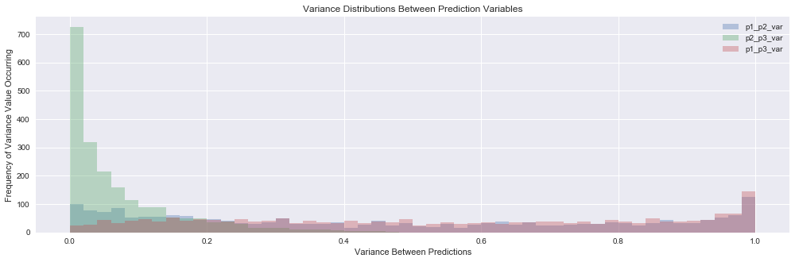

```python
img_prd_df_cln[['p1_p2_var', 'p2_p3_var', 'p1_p3_var']].plot(kind='hist',grid=True, bins=50, subplots=False,
                                                         figsize=(17,5), alpha=0.35)

# setting my labels
plt.title('Variance Distributions Between Prediction Variables')
plt.xlabel('Variance Between Predictions')
plt.ylabel('Frequency of Variance Value Occurring')
```

*Keeping the visualizations separate of one another*

```
Text(0,0.5,'Frequency')
```

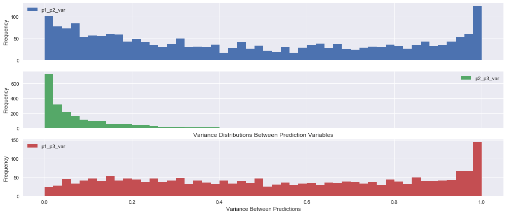

```python
img_prd_df_cln[['p1_p2_var', 'p2_p3_var', 'p1_p3_var']].plot.hist(grid=True, bins=50,
                                                                   subplots=True, figsize=(17,7))

# setting my labels
plt.title('Variance Distributions Between Prediction Variables')
plt.xlabel('Variance Between Predictions')
plt.ylabel('Frequency')
```

Taking a look at the distributions between prediction confidence percentages, I noticed something a bit odd. It seems as though the range of variance, in terms of distribution of variances or differences in prediction percentages, are far less for `p2_conf` and `p3_conf` variables, ranging from 0.0 to 0.4. This seems to make sense however, as `p2_conf` and `p3_conf` are weaker prediction percentages, compared to `p1_conf` values.

### Melted Image Prediction Dataset

```python
# reading in my cleaned data set using pandas '.read_csv()' function
img_pred_df_cpy_2 = pd.read_csv('image_prediction_mltd.csv')

img_pred_df_cpy_2.head()
```

|  | tweet_id | prediction | dg_brd_pred | pred_pct | pred_outcm | jpg_url | img_num |
| --- | --- | --- | --- | --- | --- | --- | --- |
| 0 | 666020888022790149 | p1 | Welsh springer spaniel | 0.465074 | True | https://pbs.twimg.com/media/CT4udn0WwAA0aMy.jpg | 1 |
| 1 | 666029285002620928 | p1 | redbone | 0.506826 | True | https://pbs.twimg.com/media/CT42GRgUYAA5iDo.jpg | 1 |
| 2 | 666033412701032449 | p1 | German shepherd | 0.596461 | True | https://pbs.twimg.com/media/CT4521TWwAEvMyu.jpg | 1 |
| 3 | 666044226329800704 | p1 | Rhodesian ridgeback | 0.408143 | True | https://pbs.twimg.com/media/CT5Dr8HUEAA-lEu.jpg | 1 |
| 4 | 666049248165822465 | p1 | miniature pinscher | 0.560311 | True | https://pbs.twimg.com/media/CT5IQmsXIAAKY4A.jpg | 1 |

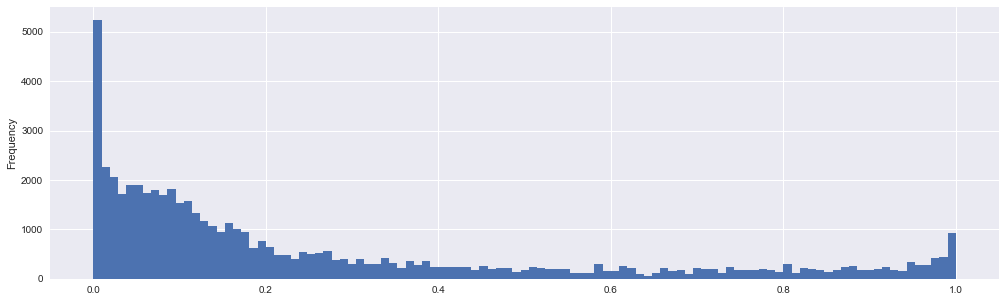

```python
img_pred_df_cpy_2['pred_pct'].plot(kind='hist', bins=105, figsize=(17, 5));
```

In my analysis of the melted image prediction data set, I chose to look at the distribution of the prediction percentage, `pred_pct` column. As we can see, a majority of prediction percentages fell below a 20% confidence, with the most counts of predictions percentages (around 5000+) nearest to 0.0.

### Twitter API Tweet Dataset

```python
twt_sts_cln_df = pd.read_csv('tweet_sts_data_cln.csv')

twt_sts_cln_df.head()
```

|  | tweet_id | favorites | favorited | retweets | retweeted |
| --- | --- | --- | --- | --- | --- |
| 0 | 892420643555336193 | 37997 | False | 8308 | False |
| 1 | 892177421306343426 | 32628 | False | 6138 | False |
| 2 | 891815181378084864 | 24551 | False | 4062 | False |
| 3 | 891689557279858688 | 41348 | False | 8453 | False |
| 4 | 891327558926688256 | 39526 | False | 9152 | False |

```python
twt_sts_cln_df.info()
```

```
<class 'pandas.core.frame.DataFrame'>
RangeIndex: 2340 entries, 0 to 2339
Data columns (total 5 columns):
tweet_id     2340 non-null int64
favorites    2340 non-null int64
favorited    2340 non-null bool
retweets     2340 non-null int64
retweeted    2340 non-null bool
dtypes: bool(2), int64(3)
memory usage: 59.5 KB
```

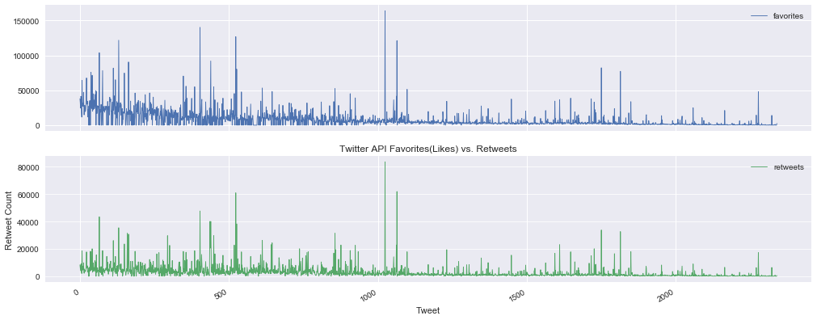

```python
twt_sts_cln_df[['favorites', 'retweets']].plot.line(grid=True, linewidth=0.9, subplots=True, figsize=(17,7))

# adding my labels
plt.title('Twitter API Favorites(Likes) vs. Retweets')
plt.xlabel('Tweet')
plt.ylabel('Retweet Count')
plt.grid(axis='y', alpha=0.75)
```

What we have here are two distribution range plots for exploratory variables `favorites` or 'Likes' and `retweets`. Using a line plot, I've been able to convey the volume of spikes, or jumps/peaks in the data, in either 'Likes' or 'Retweets'. What's interesting here is that there seems to be a spike in both variables around the same if not the same tweet. Data that reveals a pattern such as this should be explored further. Let's take a closer look.

```
Text(0,0.5,'Number of Retweets')
```

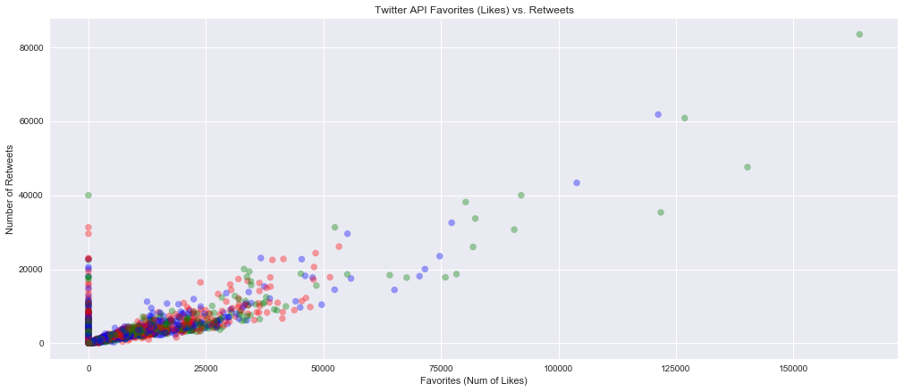

```python
x = twt_sts_cln_df['favorites']
y = twt_sts_cln_df['retweets']

colors = 'RGB'

plt.figure(figsize=(17, 7))
plt.scatter(x, y, c=colors, alpha=0.36)

# setting my labels
plt.title('Twitter API Favorites (Likes) vs. Retweets')
plt.xlabel('Favorites (Num of Likes)')
plt.ylabel('Number of Retweets')
```

Ahh, here's something interesting, and now that I think of it, should have asssumed as well. Using the scatter plot method, I've been able to convey that the relationship between 'Favorites(Likes)' and 'Retweets' is linear. This means that there is definitely a positive association between to two epxloratory variables, and in exlploratory analysis, and predictive modeling, either variable could be used as a predictor variable to forcast or predict the other. To further solidify my analysis, this inference is and should be confirmed by the line plot above, that conveys spikes within the distributions on the same tweet count.

### Twitter Data Combined Dataset

```python
twt_data_cmbd_df = pd.read_csv('twitter_archive_master.csv')
```

```python
# taking a look a the columns in the data set
twt_data_cmbd_df.columns
```

```
Index(['tweet_id', 'timestamp', 'source', 'text', 'rating_numerator',
       'rating_denominator', 'name', 'tweet_status_url', 'dog_stage',
       'jpg_url', 'img_num', 'p1', 'p1_conf', 'p1_dog', 'p2', 'p2_conf',
       'p2_dog', 'p3', 'p3_conf', 'p3_dog', 'favorites', 'favorited',
       'retweets', 'retweeted'],
      dtype='object')
```

```python
# taking a look at the prediction confidence means for dog stages
twt_data_cmbd_df.groupby('dog_stage')[['p1_conf', 'p2_conf', 'p3_conf']].mean()
```

| dog_stage | p1_conf | p2_conf | p3_conf |
| --- | --- | --- | --- |
| doggo | 0.592996 | 0.113622 | 0.058803 |
| doggo, pupper | 0.495202 | 0.203103 | 0.080413 |
| floofer | 0.444456 | 0.185075 | 0.084119 |
| pupper | 0.591276 | 0.132654 | 0.060284 |
| pupper, doggo | 0.597111 | 0.142993 | 0.136712 |
| pupper, doggo, doggo | 0.869804 | 0.079814 | 0.013263 |
| pupper, pupper | 0.446901 | 0.190128 | 0.080244 |
| pupper, pupper, pupper | 0.186498 | 0.139028 | 0.125940 |
| puppo | 0.594364 | 0.127601 | 0.065903 |
| puppo, doggo | 0.723313 | 0.218477 | 0.041276 |

```python
dg_stg_cnf_mns = twt_data_cmbd_df.groupby('dog_stage')[['p1_conf', 'p2_conf', 'p3_conf']].mean()
```

```
Text(0,0.5,'Prediction Confidence Percentage')
```

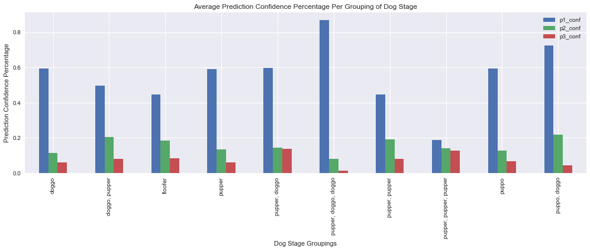

```python
dg_stg_cnf_mns.plot(kind='bar', figsize=(17, 5));

# setting my labels
plt.title('Average Prediction Confidence Percentage Per Grouping of Dog Stage')
plt.xlabel('Dog Stage Groupings')
plt.ylabel('Prediction Confidence Percentage')
```

Ok, so here we have grouped the dog stages by the column `dog_stage`'s values. I've plotted the mean or average prediction values for each dog stage grouping. We can see the grouping 'pupper, doggo, doggo' has the highest confidence percentage for p1 predictions at .87 or 87%. On the reverse, it looks like the grouping 'pupper, pupper, pupper' has the lowest p1 confidence percentage mean at .19 or 19%.

```python
# taking a look at the 'favorites' or likes and 'retweets' count for various dog stage groupings
twt_data_cmbd_df.groupby('dog_stage')[['favorites', 'retweets']].mean()
```

| dog_stage | favorites | retweets |
| --- | --- | --- |
| doggo | 11042.693333 | 4095.746667 |
| doggo, pupper | 6595.200000 | 2040.000000 |
| floofer | 12358.500000 | 4328.250000 |
| pupper | 5741.343478 | 2005.821739 |
| pupper, doggo | 7512.000000 | 3132.000000 |
| pupper, doggo, doggo | 6867.000000 | 1308.000000 |
| pupper, pupper | 4458.285714 | 1534.000000 |
| pupper, pupper, pupper | 770.000000 | 176.000000 |
| puppo | 15751.222222 | 5148.296296 |
| puppo, doggo | 25027.000000 | 5861.000000 |

```python
dg_stg_fv_vs_rt_mns = twt_data_cmbd_df.groupby('dog_stage')[['favorites', 'retweets']].mean()
```

```
Text(0,0.5,'Favorete and Retweet Counts')
```

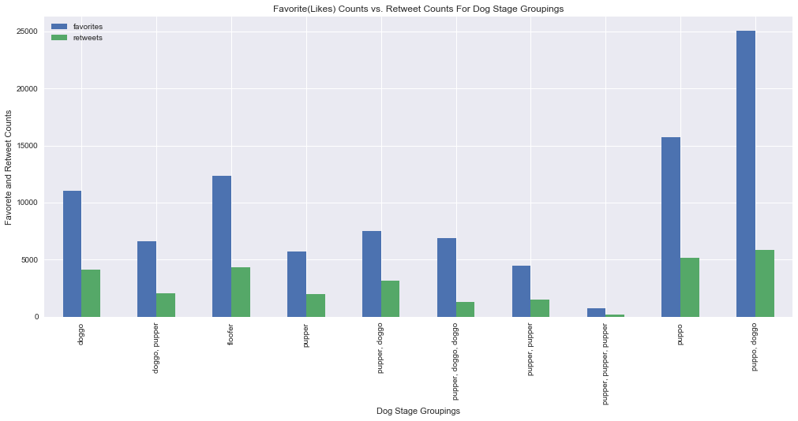

```python
dg_stg_fv_vs_rt_mns.plot(kind='bar', figsize=(17, 7));

# setting my labels
plt.title('Favorite(Likes) Counts vs. Retweet Counts For Dog Stage Groupings')
plt.xlabel('Dog Stage Groupings')
plt.ylabel('Favorete and Retweet Counts')
```

It looks here as though, the grouping 'puppo, doggo' had the highest mean or average number of 'Likes' or 'favorites' at 25,027, while the groupping 'pupper, pupper, pupper' had the lowest average number of 'Likes' at 770.

```python
# taking a look at the 'favorites' or likes and 'retweets' 'describe()' method for various dog stage groupings
twt_data_cmbd_df.groupby('dog_stage')[['favorites', 'retweets']].describe()
```

| dog_stage | favorites count | favorites mean | favorites std | favorites min | favorites 25% | favorites 50% | favorites 75% | favorites max | retweets count | retweets mean | retweets std | retweets min | retweets 25% | retweets 50% | retweets 75% | retweets max |
| --- | --- | --- | --- | --- | --- | --- | --- | --- | --- | --- | --- | --- | --- | --- | --- | --- |
| doggo | 75.0 | 11042.693333 | 10037.490869 | 0.0 | 3754.00 | 10294.0 | 14571.00 | 55081.0 | 75.0 | 4095.746667 | 4527.902274 | 3.0 | 1506.00 | 2409.0 | 5233.5 | 22746.0 |
| doggo, pupper | 5.0 | 6595.200000 | 3358.738260 | 3194.0 | 4156.00 | 5493.0 | 8996.00 | 11137.0 | 5.0 | 2040.000000 | 1014.318244 | 906.0 | 1317.00 | 2082.0 | 2374.0 | 3521.0 |
| floofer | 4.0 | 12358.500000 | 16357.668834 | 0.0 | 4390.50 | 6492.5 | 14460.50 | 36449.0 | 4.0 | 4328.250000 | 2965.830449 | 1668.0 | 1826.25 | 4201.0 | 6703.0 | 7243.0 |
| pupper | 230.0 | 5741.343478 | 8260.283845 | 0.0 | 1878.75 | 3218.0 | 5445.25 | 77280.0 | 230.0 | 2005.821739 | 3280.421152 | 4.0 | 599.25 | 1071.0 | 1978.0 | 32601.0 |
| pupper, doggo | 1.0 | 7512.000000 | NaN | 7512.0 | 7512.00 | 7512.0 | 7512.00 | 7512.0 | 1.0 | 3132.000000 | NaN | 3132.0 | 3132.00 | 3132.0 | 3132.0 | 3132.0 |
| pupper, doggo, doggo | 1.0 | 6867.000000 | NaN | 6867.0 | 6867.00 | 6867.0 | 6867.00 | 6867.0 | 1.0 | 1308.000000 | NaN | 1308.0 | 1308.00 | 1308.0 | 1308.0 | 1308.0 |
| pupper, pupper | 7.0 | 4458.285714 | 5337.792075 | 972.0 | 1957.50 | 2705.0 | 3632.00 | 16352.0 | 7.0 | 1534.000000 | 2101.493517 | 156.0 | 522.00 | 652.0 | 1355.0 | 6176.0 |
| pupper, pupper, pupper | 1.0 | 770.000000 | NaN | 770.0 | 770.00 | 770.0 | 770.00 | 770.0 | 1.0 | 176.000000 | NaN | 176.0 | 176.00 | 176.0 | 176.0 | 176.0 |
| puppo | 27.0 | 15751.222222 | 18404.833747 | 0.0 | 6041.50 | 11740.0 | 18843.00 | 92065.0 | 27.0 | 5148.296296 | 7363.552674 | 169.0 | 2535.00 | 3391.0 | 4814.0 | 40029.0 |
| puppo, doggo | 2.0 | 25027.000000 | 6798.124594 | 20220.0 | 22623.50 | 25027.0 | 27430.50 | 29834.0 | 2.0 | 5861.000000 | 1750.796390 | 4623.0 | 5242.00 | 5861.0 | 6480.0 | 7099.0 |

```python
twt_data_cmd_dscr_sts = twt_data_cmbd_df.groupby('dog_stage')[['favorites', 'retweets']].describe()
```

```python
twt_data_cmd_dscr_sts.index
```

```
Index(['doggo', 'doggo, pupper', 'floofer', 'pupper', 'pupper, doggo',
       'pupper, doggo, doggo', 'pupper, pupper', 'pupper, pupper, pupper',
       'puppo', 'puppo, doggo'],
      dtype='object', name='dog_stage')
```

```
No handles with labels found to put in legend.
```

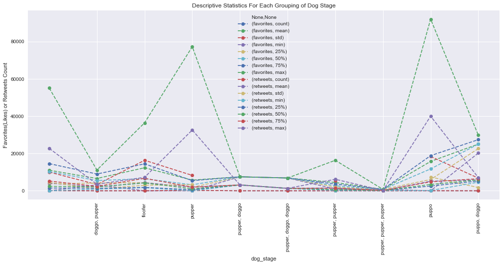

```python
# setting my labels for the graph
ticklabels = list(twt_data_cmbd_df['dog_stage'])

# creating my matplotlib object
twt_data_cmd_dscr_sts_fig, ax = plt.subplots(figsize=(17, 7))

# setting the labels on my matplotlib object
ax.set_xticks(np.arange(1,12))
ax.set_xticklabels(ticklabels)
ax.set_xlabel('Dog Stage Groupings')
ax.set_ylabel('Favorites(Likes) or Retweets Count')
ax.set_title('Descriptive Statistics For Each Grouping of Dog Stage')
ax.legend(loc='center left', frameon=False, ncol=4)
twt_data_cmd_dscr_sts.plot(kind='line', ax=ax, label=ticklabels, rot=90, legend=True, marker='o',
                           style='--', figsize=(17, 7));
```

```
Text(0.5,0,'Counts')
```

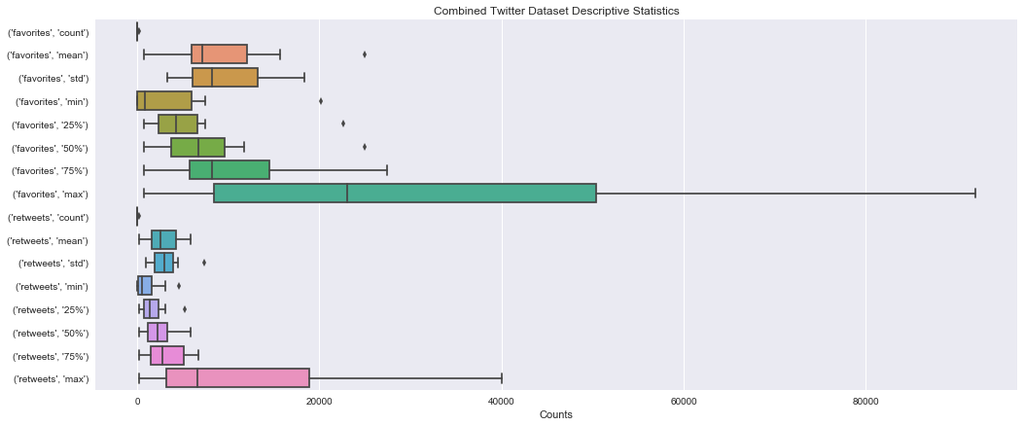

```python
# plotting with seaborn, the same descriptive statistics from above.
fig, ax = plt.subplots(figsize=(17, 7))

sns.boxplot(data=twt_data_cmd_dscr_sts, ax=ax, orient='h');

# setting my labels
plt.title('Combined Twitter Dataset Descriptive Statistics')
plt.xlabel('Counts')
```

The above two plots are just different approaches to looking at grouped data. The first, 'Descriptive Statistics For Each Grouping of Dog Stage', uses a line plot to view the distribution of descriptive statistic values for each grouping of dog stages. The second plot, 'Combined Twitter Dataset Descriptive Statistics' is also grouped by dog stage groupings, but focuses more on displaying the descriptive stats using the boxplot method.

### Conclusions

We've been able to take a brief synopsis of my analysis, and wrangling efforts and condense it into a short little report. I'm not one for Twitter much, although I do have a profile, and I find it astounding that people have the time to manage their social media profiles as much as they do; especially Twitter, which for me, is literally "tell the world every breathing moment of your life, and do it under a 140 characters." It just seems like too much to me. That being said, it's quite clear that from my analysis hundreds of thousands of people think differently.

@WeRateDogs has garnered quite the popularity on the social media platform. Analyzing their data helped me understand a few things about the user of the platform. Now this observation is obviously biased, because I've only assesed one user's data for a certain period of time, but it seems as though @WeRateDogs preferred method of 'posting' seems to be their iPhone. 94% of their tweets are delivered through the device. We also recognized the linear relationship between 'favorites' or 'likes' and 'retweets'.

I had few limitations when it came to wrangling this tweet data. For one, querying an API was new exposure for me so that learning curve took a little while to get past. Handling JSON data formatting as well, with understanding when to use `load(s)()` vs. `dump(s)()` took a few attempts at re-reading 'Read a File Line-by-Line in Python' from 'Stackabuse.com'. I surprisingly found structural or tidyness issues to be easier to fix than data quality issues. But, I guess that is to be expected considering I was using RegEx's `.str.extract()` and `.str.replace()` methods to do a bit of cleaning. My inexperience with Twitter's platform leaves a lot wanting when it comes to what data to extract or query the API for. I hope with more exposure and time, I can come back to this project and really fix it up nice.

### Resources

- Udacity Data Analyst course material
- Google/Stackoverflow
- Python: Crash Course by Eric Matthes